# Exploratory Data Analysis

SIMONE RAY

# Exploratory data analysis – Honey production in the US from 1998-2012

Dataset can be found at https://www.kaggle.com/jessicali9530/honey-production

Questions to consider:

1. How has honey production yield changed from 1998 to 2012?
2. Over time, which states produce the most honey? Which produce the least? Which have experienced the most change in honey yield?
3. Does the data show any trends in terms of the number of honey producing colonies and yield per colony before vs. after 2006, which was when concern over Colony Collapse Disorder spread nationwide?
4. Are there any patterns that can be observed between total honey production and value of production over this time period?
5. How has value of production, which in some sense could be tied to demand, changed over this time period?

```
## SUMMARY OF DATA
```

```
##      state         numcol        yieldpercol       totalprod
##  AL     : 15   Min.   :  2000   Min.   : 19.00   Min.   :   84000
##  AR     : 15   1st Qu.:  9000   1st Qu.: 48.00   1st Qu.:  475000
##  AZ     : 15   Median : 26000   Median : 60.00   Median : 1533000
##  CA     : 15   Mean   : 60284   Mean   : 62.01   Mean   : 4169086
##  CO     : 15   3rd Qu.: 63750   3rd Qu.: 74.00   3rd Qu.: 4175250
##  FL     : 15   Max.   :510000   Max.   :136.00   Max.   :46410000
##  (Other):536
##      stocks           priceperlb       prodvalue             year
##  Min.   :    8000   Min.   :0.4900   Min.   :  162000   Min.   :1998
##  1st Qu.:  143000   1st Qu.:0.9325   1st Qu.:  759250   1st Qu.:2001
##  Median :  439500   Median :1.3600   Median : 1841500   Median :2005
##  Mean   : 1318859   Mean   :1.4096   Mean   : 4715741   Mean   :2005
##  3rd Qu.: 1489500   3rd Qu.:1.6800   3rd Qu.: 4703250   3rd Qu.:2009
##  Max.   :13800000   Max.   :4.1500   Max.   :69615000   Max.   :2012
##
```

```
## ANALYSIS OF TRENDS IN TOTAL PRODUCTION AND PRODUCTION VALUE
```

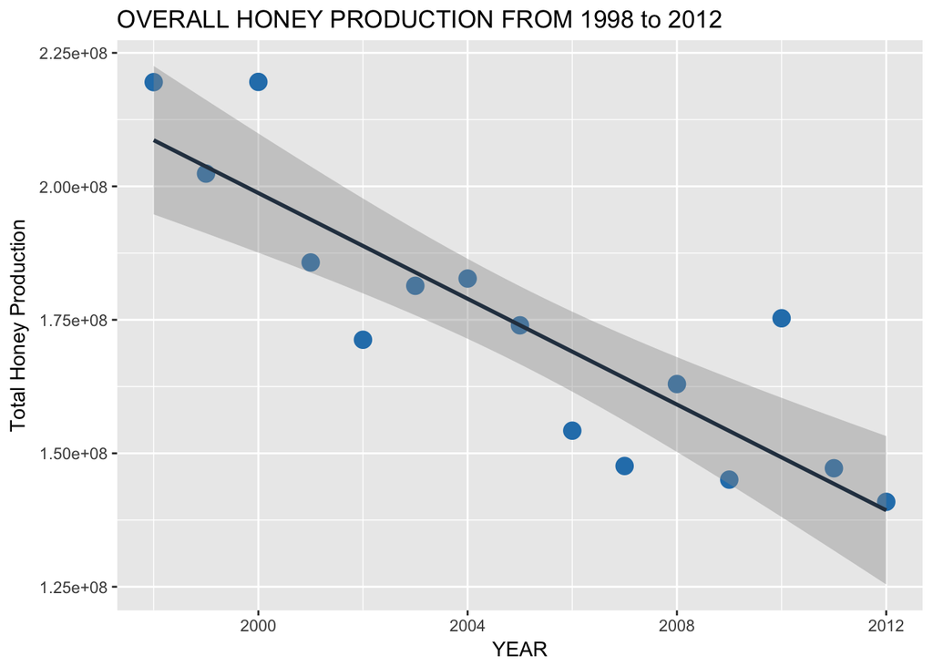

```
## In the above graph we can see that from 1998 to 2012, the overall amount of honey production across the United States has declined.
```

```
## Now let's look at price per lb.
```

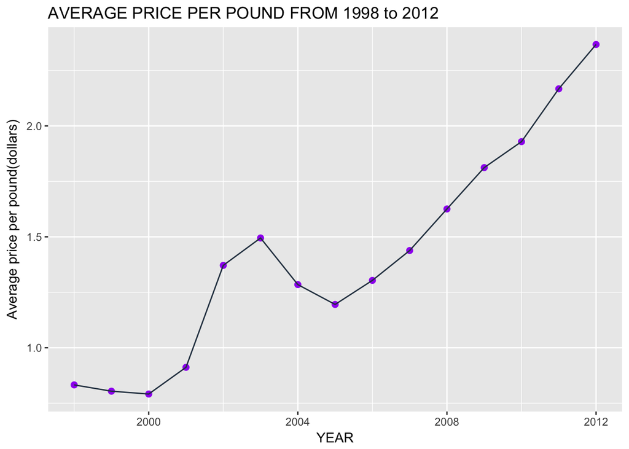

```
## The price per pound has shot up significantly since 1998.
```

```
## Now let's analyze value of production.
```

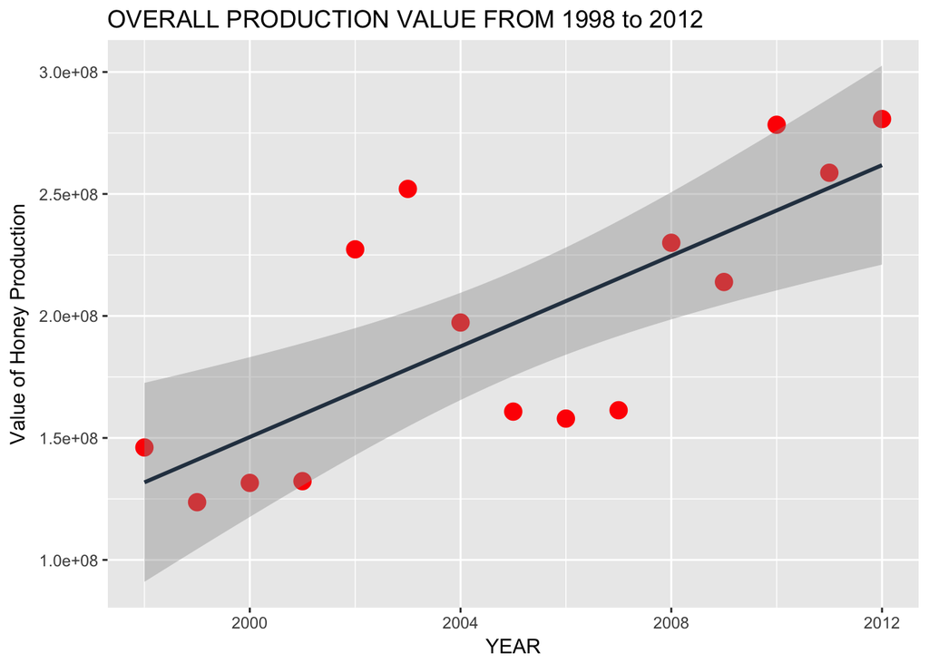

[output not shown]

```
## The following graph depicts the trends in total production and value of production in the same plot.
```

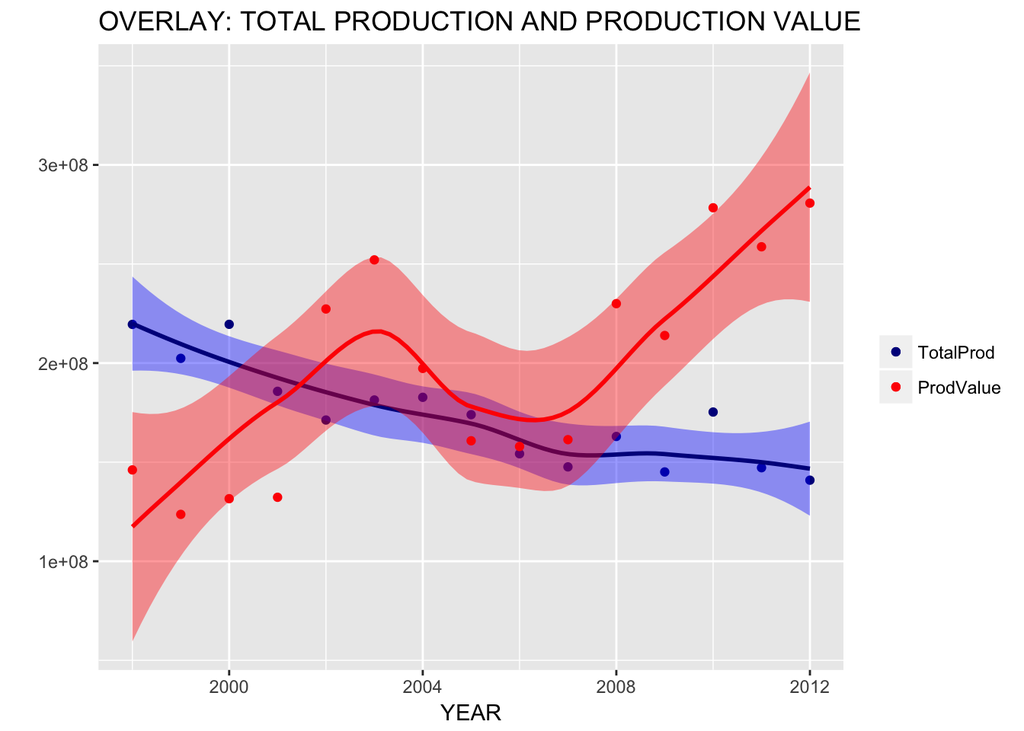

```
## Clearly, value of production has gone up, and overall production has gone down. This means that honey is slowly getting rarer and more expensive in the United States.
```

```
## 2006: COLONY COLLAPSE ANALYSIS
```

```
## Examining number of honeybee colonies before 2006 and after 2006.
```

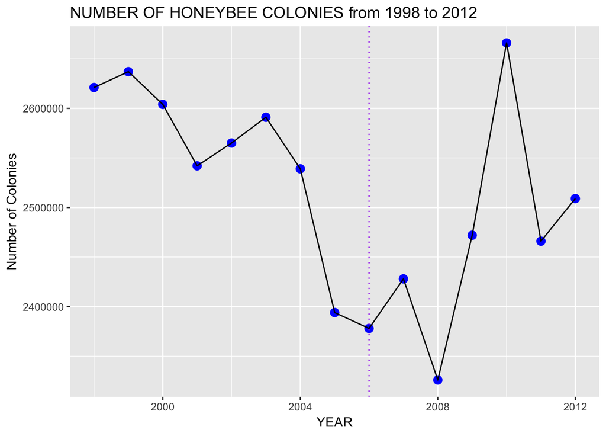

```
## Examining yield per colony before 2006 and after 2006.
```

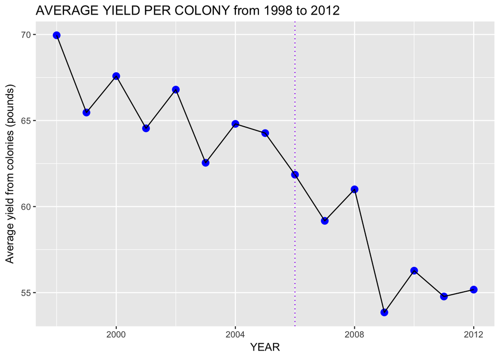

[output not shown]

[output not shown]

```
## NOW EXAMINING HONEY PRODUCTION IN EACH STATE:
```

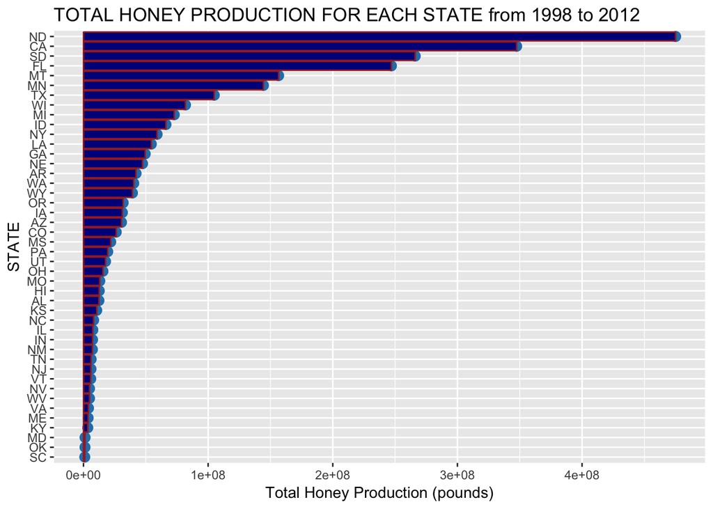

```
## The graph above shows the total honey production for each state, in descending order.
```

```
## The TOP honey producing states from 1998 to 2012.
```

```
## # A tibble: 6 x 2
##   state StateProd
##   <fct>     <dbl>
## 1 ND    475085000
## 2 CA    347535000
## 3 SD    266141000
## 4 FL    247048000
## 5 MT    156562000
## 6 MN    144360000
```

```
## The state which produced the most honey from 1998 to 2012 was North Dakota. North Dakota was followed by California, South Dakota, Florida, Montana, and Minnesota.
```

```
## The BOTTOM honey producing states from 1998 to 2012.
```

```
## # A tibble: 6 x 2
##   state StateProd
##   <fct>     <dbl>
## 1 VA      3998000
## 2 ME      3701000
## 3 KY      3445000
## 4 MD      1266000
## 5 OK      1207000
## 6 SC      1030000
```

```
## The state which produced the least honey from 1998 to 2012 was South Carolina. Other States which produced the least amount of honey over this time period include Oklahama, Maryland, Kentucky, Maine and Virginia.
```

```
## Now, analyzing the correlation of a few variables with time. Correlation has a value from 1 to -1. A positive correlation implies positive growth over time and a negative correlation implies negative growth over time. A correlation value of 0 implies no evident growth.
```

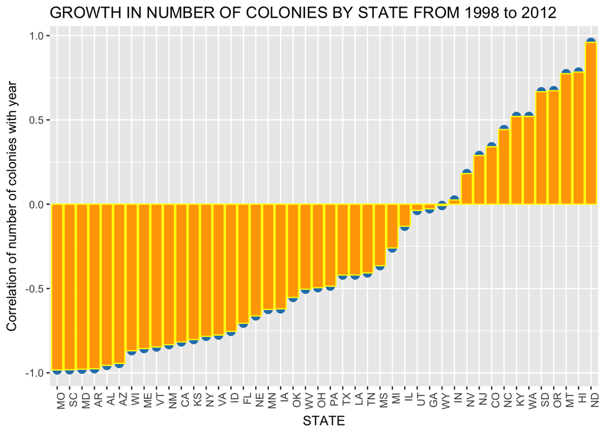

[output not shown]

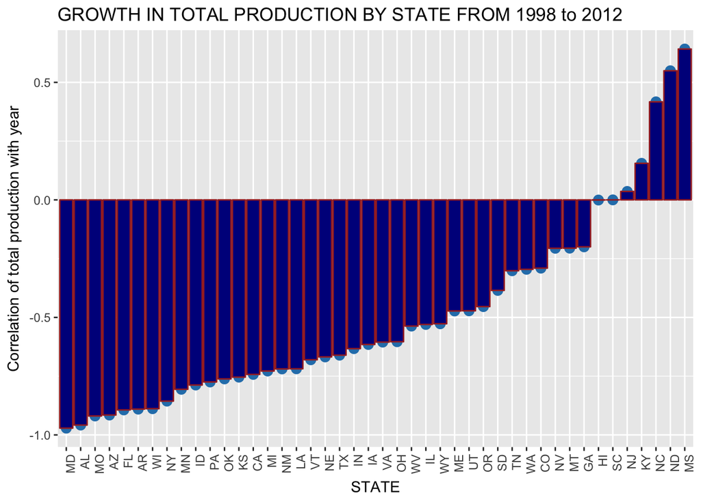

[output not shown]

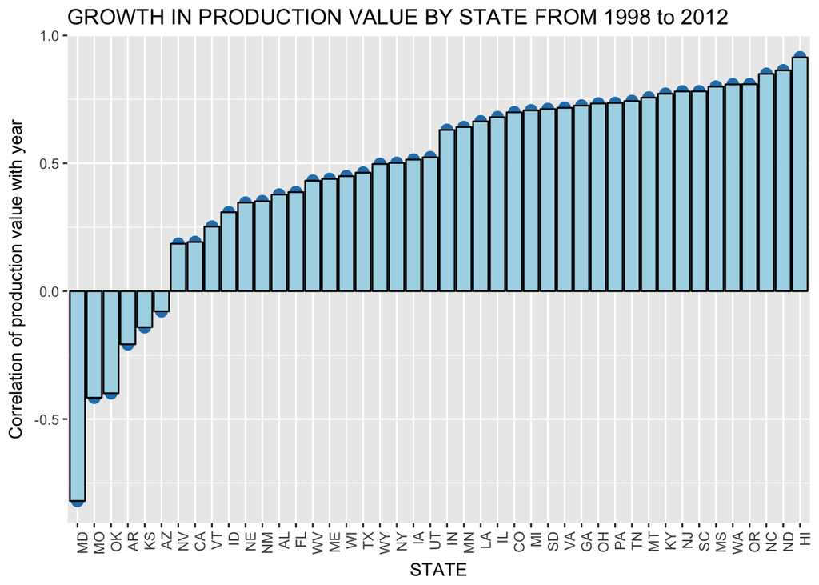

[output not shown]

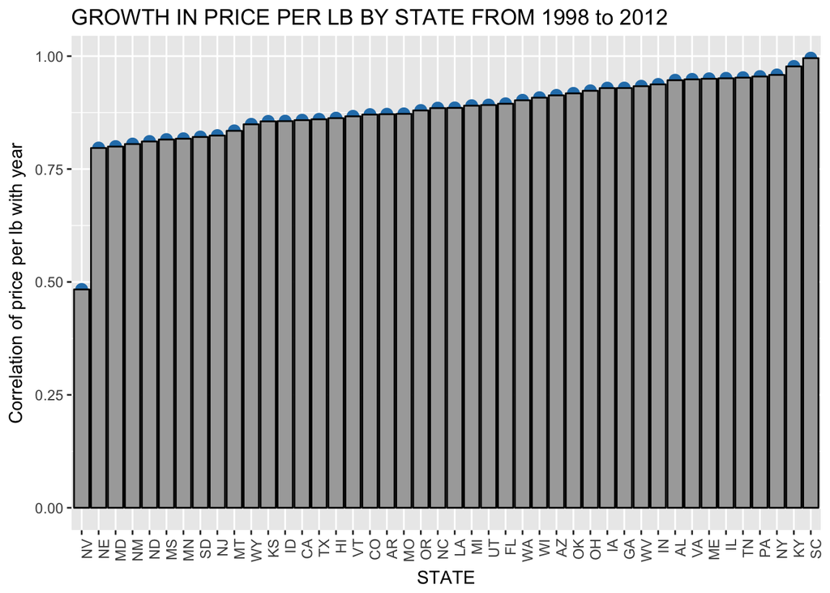

```
## This graph shows the correlation between price/lb and the year, for every state. There is a positive correlation for all states, i.e. price/lb of honey has steadily increased all across the country since 1998.
```

[output not shown]